# Session 2: Homework 1

**Author:** Answer key

**Date:** 2026

```python
# Import required libraries

import pandas as pd
import matplotlib.pyplot as plt
import seaborn as sns
import numpy as np                 # numpy is a comprehensive library with several mathematical functions
import yfinance as yf              # yfinance fetches stock data directly from Yahoo finance for use in projects
from datetime import datetime      # library with tools for manipulating & handling dates/times
import matplotlib.cm as cm         # colour palettes for visuals
import matplotlib.ticker as mtick  # used in building visuals
import warnings                    # this is used to control how warnings are handled in our project
from skimpy import skim            # Used for generating summary statistics of DataFrames


warnings.filterwarnings('ignore')  # we have decided to suppress all warning messages for this project

# Set style for better looking plots
plt.style.use('seaborn-v0_8')
sns.set_palette("husl")
plt.rcParams['figure.figsize'] = (6.75, 6.75)
```

# Analysis of movies- IMDB dataset

We will look at a subset sample of movies, taken from the [Kaggle IMDB 5000 movie dataset](https://www.kaggle.com/carolzhangdc/imdb-5000-movie-dataset)

```python
# Load movies data

movies = pd.read_csv("https://raw.githubusercontent.com/kostis-christodoulou/am01-code-sep2026/main/data/movies.csv")


# Printing out information of the dataset
movies.info()

# Printing quik summary stats
movies.describe()
```

```
<class 'pandas.core.frame.DataFrame'>
RangeIndex: 2961 entries, 0 to 2960
Data columns (total 11 columns):
 #   Column               Non-Null Count  Dtype
---  ------               --------------  -----
 0   title                2961 non-null   object
 1   genre                2961 non-null   object
 2   director             2961 non-null   object
 3   year                 2961 non-null   int64
 4   duration             2961 non-null   int64
 5   gross                2961 non-null   int64
 6   budget               2961 non-null   int64
 7   cast_facebook_likes  2961 non-null   int64
 8   votes                2961 non-null   int64
 9   reviews              2961 non-null   int64
 10  rating               2961 non-null   float64
dtypes: float64(1), int64(7), object(3)
memory usage: 254.6+ KB
```

|  | year | duration | gross | budget | cast_facebook_likes | votes | reviews | rating |
| --- | --- | --- | --- | --- | --- | --- | --- | --- |
| count | 2961.000000 | 2961.00000 | 2.961000e+03 | 2.961000e+03 | 2961.000000 | 2.961000e+03 | 2961.000000 | 2961.000000 |
| mean | 2002.901385 | 109.64539 | 5.809040e+07 | 4.061938e+07 | 12393.760892 | 1.093075e+05 | 503.305302 | 6.389227 |
| std | 9.946227 | 22.17132 | 7.246962e+07 | 4.368201e+07 | 20530.107207 | 1.581439e+05 | 493.736710 | 1.051625 |
| min | 1920.000000 | 37.00000 | 7.030000e+02 | 2.180000e+02 | 0.000000 | 5.000000e+00 | 2.000000 | 1.600000 |
| 25% | 1999.000000 | 95.00000 | 1.227681e+07 | 1.100000e+07 | 2241.000000 | 1.991800e+04 | 199.000000 | 5.800000 |
| 50% | 2004.000000 | 106.00000 | 3.470323e+07 | 2.600000e+07 | 4604.000000 | 5.574900e+04 | 364.000000 | 6.500000 |
| 75% | 2010.000000 | 119.00000 | 7.559029e+07 | 5.500000e+07 | 16926.000000 | 1.333480e+05 | 631.000000 | 7.100000 |
| max | 2016.000000 | 330.00000 | 7.605058e+08 | 3.000000e+08 | 656730.000000 | 1.689764e+06 | 5312.000000 | 9.300000 |

Besides the obvious variables of title, genre, director, year, and duration, the rest of the variables are as follows:

- gross : The gross earnings in the US box office, not adjusted for inflation
- budget: The movie's budget
- cast_facebook_likes: the number of facebook likes cast memebrs received
- votes: the number of people who voted for (or rated) the movie in IMDB
- reviews: the number of reviews for that movie
- rating: IMDB average rating

## Use your data import, inspection, and cleaning skills to answer the following:

### Missing values and duplicates

Are there any missing values (NAs)? Are all entries distinct or are there duplicate entries?

```python
# Missing values and duplicates

# Count NAs per column, then check for fully-duplicated rows and repeated titles.
missing_by_col = movies.isna().sum()

print("Missing values per column:")
print(missing_by_col[missing_by_col > 0] if missing_by_col.any()
      else "None — no missing values.")

print(f"\nFully duplicated rows: {movies.duplicated().sum()}")
print(f"Duplicate titles (same film listed more than once): "
      f"{movies.duplicated(subset='title').sum()}")
```

```
Missing values per column:
None — no missing values.

Fully duplicated rows: 0
Duplicate titles (same film listed more than once): 54
```

### Count of movies by genre

Produce a table with the count of movies by genre, ranked in descending order.

```python
# Count of movies by genre

# Count of movies by genre

# value_counts() already sorts descending; tidy it into a labelled table.
movies_by_genre = (
    movies["genre"]
    .value_counts()
    .rename_axis("genre")
    .reset_index(name="count")
)
movies_by_genre
```

|  | genre | count |
| --- | --- | --- |
| 0 | Comedy | 848 |
| 1 | Action | 738 |
| 2 | Drama | 498 |
| 3 | Adventure | 288 |
| 4 | Crime | 202 |
| 5 | Biography | 135 |
| 6 | Horror | 131 |
| 7 | Animation | 35 |
| 8 | Fantasy | 28 |
| 9 | Documentary | 25 |
| 10 | Mystery | 16 |
| 11 | Sci-Fi | 7 |
| 12 | Family | 3 |
| 13 | Musical | 2 |
| 14 | Romance | 2 |
| 15 | Western | 2 |
| 16 | Thriller | 1 |

```python
# Count of movies by genre, suing groupby()

movies_by_genre = (
    movies
    .groupby("genre")
    .agg(count=("genre", "size"))
    .sort_values("count", ascending=False)
    .reset_index()
)

movies_by_genre
```

|  | genre | count |
| --- | --- | --- |
| 0 | Comedy | 848 |
| 1 | Action | 738 |
| 2 | Drama | 498 |
| 3 | Adventure | 288 |
| 4 | Crime | 202 |
| 5 | Biography | 135 |
| 6 | Horror | 131 |
| 7 | Animation | 35 |
| 8 | Fantasy | 28 |
| 9 | Documentary | 25 |
| 10 | Mystery | 16 |
| 11 | Sci-Fi | 7 |
| 12 | Family | 3 |
| 13 | Romance | 2 |
| 14 | Musical | 2 |
| 15 | Western | 2 |
| 16 | Thriller | 1 |

### Average gross, budget, and return on budget by genre

Produce a table with the average gross earning and budget (gross and budget) by genre. Calculate a variable return_on_budget which shows how many dollars did a movie make at the box office for each dollar of its budget. Rank genres by this return_on_budget in descending order.

```python
# Average gross, budget, and return on budget by genre

# Group once, take the two means, then derive return_on_budget inside .assign()
# so the whole calculation reads as a single top-to-bottom chain.
return_by_genre = (
    movies
    .groupby("genre")
    .agg(mean_gross=("gross", "mean"),
         mean_budget=("budget", "mean"))
    .assign(return_on_budget=lambda d: d["mean_gross"] / d["mean_budget"])
    .sort_values("return_on_budget", ascending=False)
    .round(2)
    .reset_index()
)
return_by_genre
```

|  | genre | mean_gross | mean_budget | return_on_budget |
| --- | --- | --- | --- | --- |
| 0 | Musical | 9.208400e+07 | 3189500.00 | 28.87 |
| 1 | Family | 1.491605e+08 | 14833333.33 | 10.06 |
| 2 | Western | 2.082188e+07 | 3465000.00 | 6.01 |
| 3 | Documentary | 1.735397e+07 | 5887852.44 | 2.95 |
| 4 | Horror | 3.771374e+07 | 13504916.11 | 2.79 |
| 5 | Fantasy | 4.240884e+07 | 17582142.86 | 2.41 |
| 6 | Comedy | 4.263055e+07 | 24446319.40 | 1.74 |
| 7 | Mystery | 6.753302e+07 | 39218750.00 | 1.72 |
| 8 | Animation | 9.843379e+07 | 61701428.57 | 1.60 |
| 9 | Biography | 4.520181e+07 | 28543696.32 | 1.58 |
| 10 | Adventure | 9.579426e+07 | 66290069.44 | 1.45 |
| 11 | Drama | 3.746537e+07 | 26242933.47 | 1.43 |
| 12 | Crime | 3.750240e+07 | 26596169.14 | 1.41 |
| 13 | Romance | 3.126485e+07 | 25107500.00 | 1.25 |
| 14 | Action | 8.658386e+07 | 71354887.53 | 1.21 |
| 15 | Sci-Fi | 2.978837e+07 | 27607142.86 | 1.08 |
| 16 | Thriller | 2.468000e+03 | 300000.00 | 0.01 |

### Top 15 directors by gross revenue

Produce a table that shows the top 15 directors who have created the highest gross revenue in the box office. Don't just show the total gross amount, but also the mean, median, and standard deviation per director.

```python
# Top 15 directors by gross revenue

# A single groupby with named aggregations produces every statistic in one pass;
# sort by total gross and keep the 15 biggest earners.
top_directors = (
    movies
    .groupby("director")
    .agg(total_gross=("gross", "sum"),
         mean_gross=("gross", "mean"),
         median_gross=("gross", "median"),
         std_gross=("gross", "std"))
    .sort_values("total_gross", ascending=False)
    .head(15)
    .round(0)
    .reset_index()
)
top_directors
```

|  | director | total_gross | mean_gross | median_gross | std_gross |
| --- | --- | --- | --- | --- | --- |
| 0 | Steven Spielberg | 4014061704 | 174524422.0 | 164435221.0 | 101421051.0 |
| 1 | Michael Bay | 2231242537 | 171634041.0 | 138396624.0 | 127161579.0 |
| 2 | Tim Burton | 2071275480 | 129454718.0 | 76519172.0 | 108726924.0 |
| 3 | Sam Raimi | 2014600898 | 201460090.0 | 234903076.0 | 162126632.0 |
| 4 | James Cameron | 1909725910 | 318287652.0 | 175562880.0 | 309171337.0 |
| 5 | Christopher Nolan | 1813227576 | 226653447.0 | 196667606.0 | 187224133.0 |
| 6 | George Lucas | 1741418480 | 348283696.0 | 380262555.0 | 146193880.0 |
| 7 | Robert Zemeckis | 1619309108 | 124562239.0 | 100853835.0 | 91300279.0 |
| 8 | Clint Eastwood | 1378321100 | 72543216.0 | 46700000.0 | 75487408.0 |
| 9 | Francis Lawrence | 1358501971 | 271700394.0 | 281666058.0 | 135437020.0 |
| 10 | Ron Howard | 1335988092 | 111332341.0 | 101587923.0 | 81933761.0 |
| 11 | Gore Verbinski | 1329600995 | 189942999.0 | 123207194.0 | 154473822.0 |
| 12 | Andrew Adamson | 1137446920 | 284361730.0 | 279680930.0 | 120895765.0 |
| 13 | Shawn Levy | 1129750988 | 102704635.0 | 85463309.0 | 65484773.0 |
| 14 | Ridley Scott | 1128857598 | 80632686.0 | 47775715.0 | 68812285.0 |

### Ratings distribution by genre

Finally, ratings. Produce a table that describes how ratings are distributed by genre. We don't want just the mean, but also, min, max, median, SD and some kind of a histogram or density graph that visually shows how ratings are distributed.

```python
# Ratings distribution by genre

# Summarise the spread of ratings within each genre: centre (mean/median),
# extremes (min/max) and dispersion (std), sorted by mean rating.
ratings_by_genre = (
    movies
    .groupby("genre")["rating"]
    .agg(["mean", "min", "max", "median", "std", "count"])
    .sort_values("mean", ascending=False)
    .round(2)
    .reset_index()
)
ratings_by_genre
```

|  | genre | mean | min | max | median | std | count |
| --- | --- | --- | --- | --- | --- | --- | --- |
| 0 | Biography | 7.11 | 4.5 | 8.9 | 7.20 | 0.76 | 135 |
| 1 | Crime | 6.92 | 4.8 | 9.3 | 6.90 | 0.85 | 202 |
| 2 | Mystery | 6.86 | 4.6 | 8.5 | 6.90 | 0.88 | 16 |
| 3 | Musical | 6.75 | 6.3 | 7.2 | 6.75 | 0.64 | 2 |
| 4 | Drama | 6.73 | 2.1 | 8.8 | 6.80 | 0.92 | 498 |
| 5 | Documentary | 6.66 | 1.6 | 8.5 | 7.40 | 1.77 | 25 |
| 6 | Sci-Fi | 6.66 | 5.0 | 8.2 | 6.40 | 1.09 | 7 |
| 7 | Animation | 6.65 | 4.5 | 8.0 | 6.90 | 0.97 | 35 |
| 8 | Romance | 6.65 | 6.2 | 7.1 | 6.65 | 0.64 | 2 |
| 9 | Adventure | 6.51 | 2.3 | 8.6 | 6.60 | 1.09 | 288 |
| 10 | Family | 6.50 | 5.7 | 7.9 | 5.90 | 1.22 | 3 |
| 11 | Action | 6.23 | 2.1 | 9.0 | 6.30 | 1.03 | 738 |
| 12 | Fantasy | 6.15 | 4.3 | 7.9 | 6.45 | 0.96 | 28 |
| 13 | Comedy | 6.11 | 1.9 | 8.8 | 6.20 | 1.02 | 848 |
| 14 | Horror | 5.83 | 3.6 | 8.5 | 5.90 | 1.01 | 131 |
| 15 | Western | 5.70 | 4.1 | 7.3 | 5.70 | 2.26 | 2 |
| 16 | Thriller | 4.80 | 4.8 | 4.8 | 4.80 | NaN | 1 |

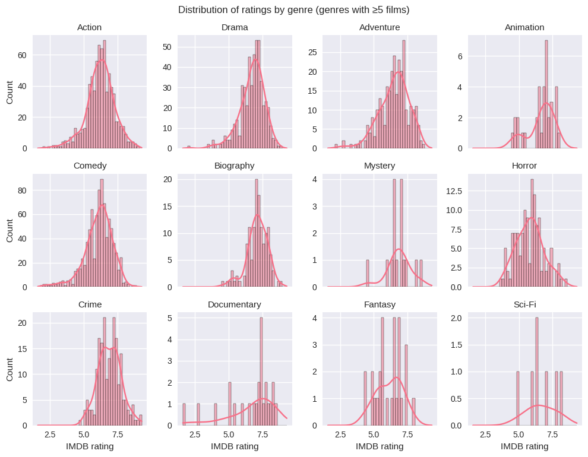

```python
# Histogram of ratings by genre

# filter for genres that have at least 5 movies
counts = movies["genre"].value_counts()
movies_big = movies[movies["genre"].isin(counts[counts >= 5].index)]

# plot all the histograms together instead of one after another, using seaborn's facet grid
g = sns.displot(
    data=movies_big,
    x="rating",
    col="genre",
    col_wrap=4,
    kind="hist",
    kde=True,                     # overlay a density curve on each histogram
    height=2.5,
    facet_kws={"sharey": False},
)
g.set_titles("{col_name}")
g.set_axis_labels("IMDB rating", "Count")
g.fig.suptitle("Distribution of ratings by genre (genres with ≥5 films)", y=1.02)
```

## Use `seaborn` to answer the following:

### Gross vs. cast Facebook likes

- Examine the relationship between `gross` and `cast_facebook_likes`. Produce a scatterplot and write one sentence discussing whether the number of facebook likes that the cast has received is likely to be a good predictor of how much money a movie will make at the box office. What variable are you going to map to the Y- and X- axes?

**Answer:** With a correlation of only about **0.21**, cast Facebook likes are a *weak* predictor of gross — the points form a very diffuse cloud and plenty of low-popularity casts still produced high-grossing films — so on their own they would make a poor predictor of box-office revenue. (Gross → Y axis, cast_facebook_likes → X axis, since gross is the outcome we are trying to explain.)

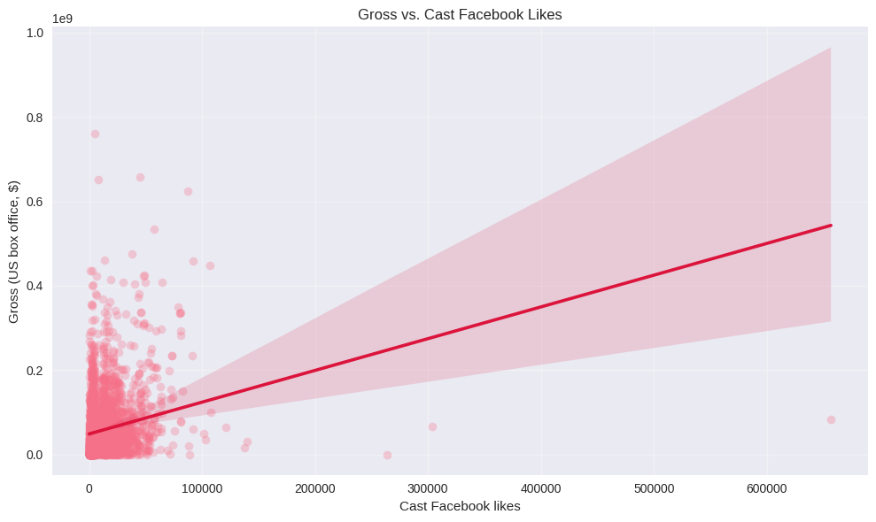

```
Correlation between gross and cast facebook likes: 0.213
```

```python
# Scatter plot: Gross vs Cast Facebook Likes

# Predictor (cast_facebook_likes) on X, outcome (gross) on Y: we ask whether more
# cast popularity is associated with higher box-office takings.
plt.figure(figsize=(10, 6))

# regplot draws the scatter, fits a linear regression line, and shades its 95% CI.
sns.regplot(
    data=movies,
    x="cast_facebook_likes",
    y="gross",
    scatter_kws={"alpha": 0.3},    # fade points so dense regions stay readable
    line_kws={"color": "crimson"},
)

plt.title("Gross vs. Cast Facebook Likes")
plt.xlabel("Cast Facebook likes")
plt.ylabel("Gross (US box office, $)")
plt.grid(True, alpha=0.3)
plt.tight_layout()
plt.show()

# Pearson correlation quantifies the (weak) linear association shown above.
correlation = movies["gross"].corr(movies["cast_facebook_likes"])
print(f"Correlation between gross and cast facebook likes: {correlation:.3f}")
```

### Gross vs. budget

- Examine the relationship between `gross` and `budget`. Produce a scatterplot and write one sentence discussing whether budget is likely to be a good predictor of how much money a movie will make at the box office.

**Answer:** Budget shows a clear positive relationship with gross (correlation ≈ **0.64**): bigger budgets tend to bring bigger box-office takings, so budget is a reasonably good — though far from perfect — predictor of gross.

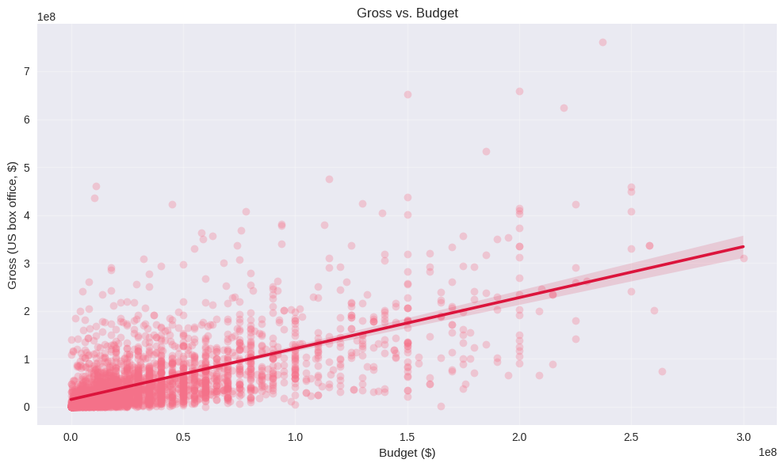

```
Correlation between gross and budget: 0.641
```

```python
# Scatter plot: Gross vs Budget

# Budget on X, gross on Y — does spending more tend to earn more at the box office?
plt.figure(figsize=(10, 6))

sns.regplot(
    data=movies,
    x="budget",
    y="gross",
    scatter_kws={"alpha": 0.3},
    line_kws={"color": "crimson"},
)

plt.title("Gross vs. Budget")
plt.xlabel("Budget ($)")
plt.ylabel("Gross (US box office, $)")
plt.grid(True, alpha=0.3)
plt.tight_layout()
plt.show()

print(f"Correlation between gross and budget: "
      f"{movies['gross'].corr(movies['budget']):.3f}")
```

### Gross vs. rating, faceted by genre

- Examine the relationship between `gross` and `rating`. Produce a scatterplot, faceted by `genre` and discuss whether IMDB ratings are likely to be a good predictor of how much money a movie will make at the box office. Is there anything strange in this dataset?

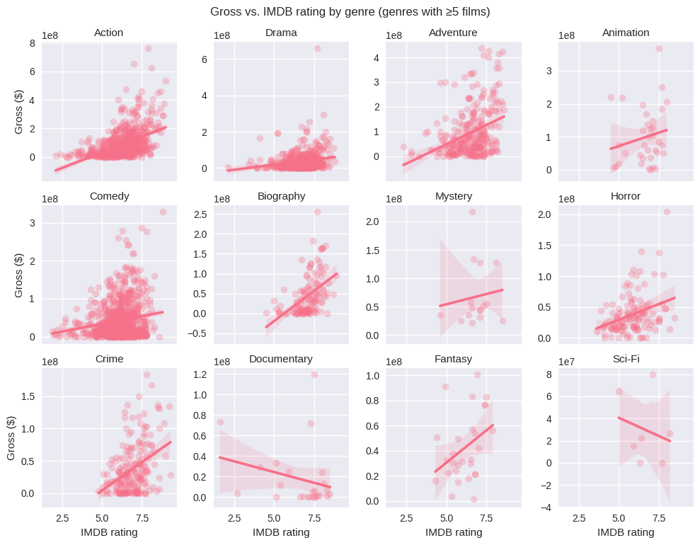

```python
# Scatter plot: Gross vs Rating by Genre- for genres that have at least 5 movies

# Reuse the ">=5 films" filter so sparse genres don't create near-empty facets.
counts = movies["genre"].value_counts()
movies_big = movies[movies["genre"].isin(counts[counts >= 5].index)]

# lmplot = scatter + fitted regression line, one facet per genre.
g = sns.lmplot(
    data=movies_big,
    x="rating",
    y="gross",
    col="genre",
    col_wrap=4,
    height=2.5,
    scatter_kws={"alpha": 0.3},
    facet_kws={"sharey": False},
)
g.set_titles("{col_name}")
g.set_axis_labels("IMDB rating", "Gross ($)")
g.fig.suptitle("Gross vs. IMDB rating by genre (genres with ≥5 films)", y=1.02)
```

# Returns of financial stocks

> You may find useful the material on [finance data sources](https://am01-sep24.netlify.app/reference/finance_data/).

We will use the `yfinance` package to download historical data of stock prices, calculate returns, and examine the distribution of returns.

We must first identify which stocks we want to download data for, and for this we must know their ticker symbol; Apple is known as AAPL, Microsoft as MSFT, McDonald's as MCD, etc. The file `nyse.csv` contains 508 stocks listed on the NYSE, their ticker `symbol`, `name`, the IPO (Initial Public Offering) year, and the sector and industry the company is in.

```python
# Load NYSE data

# Load the dataset from the relevant directory
nyse = pd.read_csv("https://raw.githubusercontent.com/kostis-christodoulou/am01-code-sep2026/main/data/nyse.csv")


# Printing out the first 10 observations
nyse.head()

# Printing out information of the dataset's variables
print("nData info: ")

nyse.info()
```

```
nData info:
<class 'pandas.core.frame.DataFrame'>
RangeIndex: 508 entries, 0 to 507
Data columns (total 6 columns):
 #   Column         Non-Null Count  Dtype
---  ------         --------------  -----
 0   symbol         508 non-null    object
 1   name           508 non-null    object
 2   ipo_year       143 non-null    float64
 3   sector         508 non-null    object
 4   industry       508 non-null    object
 5   summary_quote  508 non-null    object
dtypes: float64(1), object(5)
memory usage: 23.9+ KB
```

## Companies per sector

Based on this dataset, create a table and a bar plot that shows the number of companies per sector, in descending order

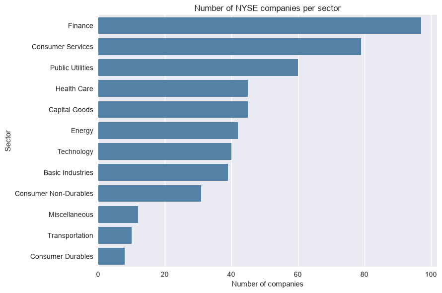

|  | sector | n_companies |
| --- | --- | --- |
| 0 | Finance | 97 |
| 1 | Consumer Services | 79 |
| 2 | Public Utilities | 60 |
| 3 | Health Care | 45 |
| 4 | Capital Goods | 45 |
| 5 | Energy | 42 |
| 6 | Technology | 40 |
| 7 | Basic Industries | 39 |
| 8 | Consumer Non-Durables | 31 |
| 9 | Miscellaneous | 12 |
| 10 | Transportation | 10 |
| 11 | Consumer Durables | 8 |

```python
# Companies per sector

# Count companies in each sector and tidy into a labelled, descending table.
companies_by_sector = (
    nyse["sector"]
    .value_counts()
    .rename_axis("sector")
    .reset_index(name="n_companies")
)

# Bar plot
plt.figure(figsize=(9, 6))
sns.barplot(data=companies_by_sector, x="n_companies", y="sector", color="steelblue")
plt.xlabel("Number of companies")
plt.ylabel("Sector")
plt.title("Number of NYSE companies per sector")
plt.tight_layout()
plt.show()

companies_by_sector
```

## Choose stocks and download data

Next, let's choose some stocks and their ticker symbols and download some data. You **MUST** choose 6 different stocks from the ones listed below; You should, however, add `SPY` which is the SP500 ETF (Exchange Traded Fund).

```python
# Download stock data

# The 6 chosen stocks plus SPY (the S&P 500 ETF)
my_stocks = ["AAPL", "JPM", "DIS", "DPZ", "ANF", "XOM", "SPY"]

# Date range: start on 1 January five years ago, end today.
# Computed from today's date so it always stays current when re-run.
end_date = pd.Timestamp.today().normalize()
start_date = pd.Timestamp(year=end_date.year - 5, month=1, day=1)

# Download every ticker in ONE call. Passing a list to yf.download returns a
# frame with a two-level column index (field, ticker); selecting "Adj Close"
# collapses it to a tidy price matrix: dates on the index, one column per stock.
prices = yf.download(
    my_stocks,
    start=start_date,
    end=end_date,
    auto_adjust=False,   # keep the explicit "Adj Close" column
    progress=False,
)["Adj Close"]

# yfinance returns the columns alphabetically, so reorder to match our list.
prices = prices[my_stocks]

print(f"Downloaded {start_date.date()} to {end_date.date()}")
print("Adjusted-close price matrix:", prices.shape)   # (trading days, stocks)
prices.head()
```

```
Downloaded 2021-01-01 to 2026-09-08
Adjusted-close price matrix: (1425, 7)
```

| Ticker Date | AAPL | JPM | DIS | DPZ | ANF | XOM | SPY |
| --- | --- | --- | --- | --- | --- | --- | --- |
| 2021-01-04 | 125.632523 | 109.000526 | 172.271988 | 352.243988 | 20.490000 | 33.251331 | 342.436920 |
| 2021-01-05 | 127.185791 | 109.593620 | 173.008865 | 353.951843 | 21.370001 | 34.853798 | 344.795380 |
| 2021-01-06 | 122.904526 | 114.739677 | 173.668137 | 357.228363 | 22.240000 | 35.743176 | 346.856750 |
| 2021-01-07 | 127.098434 | 118.507668 | 173.144592 | 355.669067 | 21.209999 | 36.023605 | 352.010223 |
| 2021-01-08 | 128.195419 | 118.638519 | 173.251236 | 360.904022 | 21.530001 | 36.424225 | 354.015839 |

## Calculate daily and monthly returns

Financial performance analysis depend on returns; If I buy a stock today for 100 and I sell it tomorrow for 101.75, my one-day return, assuming no transaction costs, is 1.75%. So given the adjusted closing prices, our first step is to calculate daily and monthly returns.

```python
# Calculate returns

# pct_change() on the whole DataFrame computes returns for every stock at once.
daily_returns = prices.pct_change()

# Resample to month-end ("ME") / year-end ("YE"), take the last price in each
# period, then compute the percentage change. (Older pandas uses "M" / "Y".)
monthly_returns = prices.resample("ME").last().pct_change()
yearly_returns  = prices.resample("YE").last().pct_change()

monthly_returns.head()
```

| Ticker Date | AAPL | JPM | DIS | DPZ | ANF | XOM | SPY |
| --- | --- | --- | --- | --- | --- | --- | --- |
| 2021-01-31 | NaN | NaN | NaN | NaN | NaN | NaN | NaN |
| 2021-02-28 | -0.079712 | 0.143778 | 0.124101 | -0.065406 | 0.186389 | 0.233125 | 0.027806 |
| 2021-03-31 | 0.007340 | 0.034382 | -0.023910 | 0.064204 | 0.253562 | 0.026853 | 0.045399 |
| 2021-04-30 | 0.076218 | 0.016330 | 0.008129 | 0.148318 | 0.092684 | 0.025256 | 0.052911 |
| 2021-05-31 | -0.050497 | 0.067811 | -0.039619 | 0.010726 | 0.138970 | 0.034597 | 0.006566 |

## Summary of monthly returns

Create a table where you summarise monthly returns for each of the stocks and `SPY`; min, max, median, mean, SD.

```python
# Summary of monthly returns

# .agg() applies all five statistics to every column in one shot; .T puts the
# stocks on the rows and the statistics on the columns.
monthly_summary = (
    monthly_returns
    .agg(["min", "max", "median", "mean", "std"])
    .T
    .round(4)
)

print("Monthly returns summary:")
monthly_summary
```

```
Monthly returns summary:
```

| Ticker | min | max | median | mean | std |
| --- | --- | --- | --- | --- | --- |
| AAPL | -0.1223 | 0.1886 | 0.0183 | 0.0160 | 0.0706 |
| JPM | -0.1484 | 0.2154 | 0.0204 | 0.0194 | 0.0675 |
| DIS | -0.1861 | 0.2487 | -0.0134 | -0.0023 | 0.0921 |
| DPZ | -0.1944 | 0.1773 | -0.0067 | 0.0040 | 0.0919 |
| ANF | -0.4089 | 0.4374 | 0.0474 | 0.0423 | 0.1734 |
| XOM | -0.1291 | 0.2692 | 0.0239 | 0.0251 | 0.0797 |
| SPY | -0.0924 | 0.1051 | 0.0208 | 0.0129 | 0.0436 |

## Density plot of monthly returns

Plot a density plot, using `sns.kdeplot()`, for each of the stocks

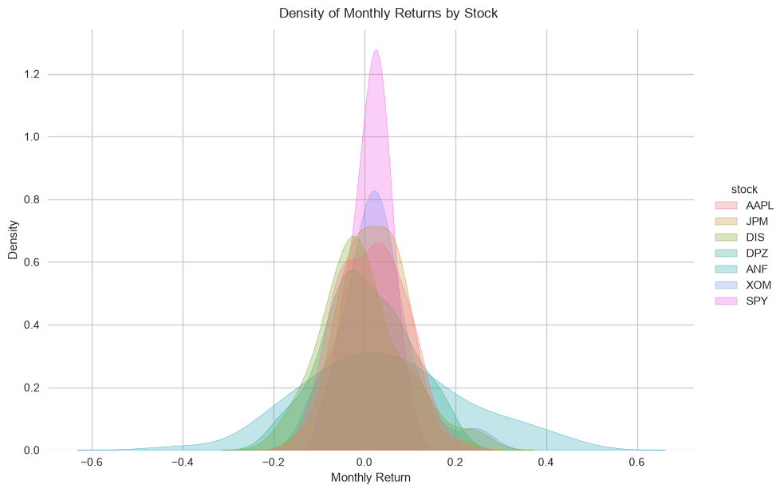

```python
# Density plot of monthly returns

# Reshape to long ("tidy") form so seaborn can colour by stock with `hue`:
# one row per (date, stock, monthly_return).
monthly_long = (
    monthly_returns
    .melt(value_name="monthly_return", var_name="stock", ignore_index=False)
    .dropna()
)

sns.set_style("whitegrid")

# displot draws every stock's KDE on a single seaborn figure, no manual loop.
g = sns.displot(
    data=monthly_long,
    x="monthly_return",
    hue="stock",
    kind="kde",
    fill=True,
    alpha=0.3,
    height=6,
    aspect=1.5,
)
g.set_axis_labels("Monthly Return", "Density")
g.fig.suptitle("Density of Monthly Returns by Stock", y=1.02)
```

What can you infer from this plot? Which stock is the riskiest? The least risky?

> TYPE YOUR ANSWER AFTER (AND OUTSIDE!) THIS BLOCKQUOTE.

## Risk-return plot

Finally, make a plot that shows the expected monthly return (mean) of a stock on the Y axis and the risk (standard deviation) in the X-axis. Please use `plt.annotate()` to label each stock

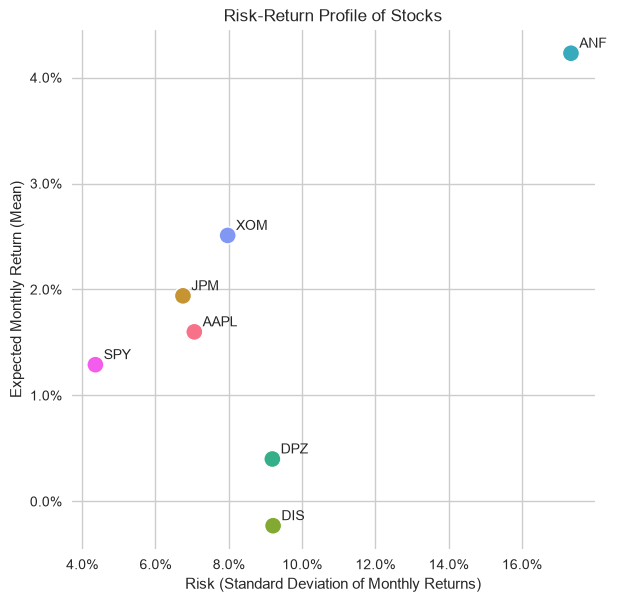

```python
# Risk-return plot
# monthly_summary already holds each stock's mean (return) and std (risk),
# so we can plot straight from it. reset_index turns the ticker into a column.
risk_return = monthly_summary.reset_index(names="stock")

sns.set_style("whitegrid")
ax = sns.scatterplot(
    data=risk_return,
    x="std",
    y="mean",
    hue="stock",
    s=150,
    legend=False,
)

# Label each point, one annotation per row.
for row in risk_return.itertuples():
    ax.annotate(row.stock, (row.std, row.mean),
                xytext=(6, 4), textcoords="offset points")

ax.set(
    xlabel="Risk (Standard Deviation of Monthly Returns)",
    ylabel="Expected Monthly Return (Mean)",
    title="Risk-Return Profile of Stocks",
)

# Format both axes as percentages with one decimal (values are decimals, so xmax=1).
ax.xaxis.set_major_formatter(mtick.PercentFormatter(xmax=1, decimals=1))
ax.yaxis.set_major_formatter(mtick.PercentFormatter(xmax=1, decimals=1))
```

What can you infer from this plot? Are there any stocks which, while being riskier, do not have a higher expected return?

> TYPE YOUR ANSWER AFTER (AND OUTSIDE!) THIS BLOCKQUOTE

**Yes.** DIS and DPZ sit to the *right* of AAPL, JPM and XOM (higher standard deviation) yet *lower* on the return axis — DIS actually posts a slightly **negative** mean monthly return despite being one of the most volatile names, so both took on extra risk without being compensated for it. At the other extreme, ANF is the riskiest name but also the highest-returning, while SPY delivers a solid return at the lowest risk — a neat illustration of the diversification benefit of holding the index rather than a single stock.

# Rents in San Francisco 2000-2018

[Kate Pennington](https://www.katepennington.org/data) created a panel of historic Craigslist rents by scraping posts archived by the Wayback Machine. You can read more about her work here:

[What impact does new housing have on rents, displacement, and gentrification in the surrounding neighborhood? Read our interview with economist Kate Pennington about her article, "Does Building New Housing Cause Displacement?:The Supply and Demand Effects of Construction in San Francisco."](https://matrix.berkeley.edu/research-article/kate-pennington-on-gentrification-and-displacement-in-san-francisco/)

In our case, we have a clean(ish) dataset with about 200K rows that correspond to Craigslist listings for renting properties in the greater SF area. The data dictionary is as follows:

| variable | class | description |
| --- | --- | --- |
| post_id | character | Unique ID |
| date | double | date |
| year | double | year |
| nhood | character | neighborhood |
| city | character | city |
| county | character | county |
| price | double | price in USD |
| beds | double | n of beds |
| baths | double | n of baths |
| sqft | double | square feet of rental |
| room_in_apt | double | room in apartment |
| address | character | address |
| lat | double | latitude |
| lon | double | longitude |
| title | character | title of listing |
| descr | character | description |
| details | character | additional details |

The dataset was used in a recent [tidyTuesday](https://github.com/rfordatascience/tidytuesday) project.

```python
# Download rent data

rent = pd.read_csv('https://raw.githubusercontent.com/rfordatascience/tidytuesday/master/data/2022/2022-07-05/rent.csv')


print("Data shape:", rent.shape)

print("\nData info:")

# Printing the dataset's variables, their data types etc.
print(rent.info())
```

```
Data shape: (200796, 17)

Data info:
<class 'pandas.core.frame.DataFrame'>
RangeIndex: 200796 entries, 0 to 200795
Data columns (total 17 columns):
 #   Column       Non-Null Count   Dtype
---  ------       --------------   -----
 0   post_id      200796 non-null  object
 1   date         200796 non-null  int64
 2   year         200796 non-null  int64
 3   nhood        200796 non-null  object
 4   city         200796 non-null  object
 5   county       199402 non-null  object
 6   price        200796 non-null  int64
 7   beds         194188 non-null  float64
 8   baths        42675 non-null   float64
 9   sqft         64679 non-null   float64
 10  room_in_apt  200796 non-null  int64
 11  address      3908 non-null    object
 12  lat          7651 non-null    float64
 13  lon          4312 non-null    float64
 14  title        198279 non-null  object
 15  descr        3254 non-null    object
 16  details      8016 non-null    object
dtypes: float64(5), int64(4), object(8)
memory usage: 26.0+ MB
None
```

## Variable types and missing values

What are the variable types? Do they all correspond to what they really are? Which variables have most missing values?

**Answer:** Most columns are typed sensibly — `price`, `beds`, `baths`, `sqft`, `lat`, `lon` are numeric and the text fields are objects. The main mismatch is `date`, stored as an integer (YYYYMMDD) rather than a true datetime, while `year` is a number that really behaves as a category. The columns with the most missing values are the free-text and geolocation fields — `descr`, `address`, `lon`, `lat`, `details` — followed by `baths` and `sqft`; the core fields such as `price`, `city` and `year` are essentially complete.

```python
# Data inspection

# Calculating the total no. of missing values in each column of the dataset,
# sorted so the worst offenders are at the top (with a % for context).
missing = (
    rent.isna().sum()
    .sort_values(ascending=False)
    .rename("n_missing")
    .to_frame()
    .assign(pct_missing=lambda d: (d["n_missing"] / len(rent) * 100).round(1))
)
print("Missing values by column:")
print(missing.head(10))

# Printing out the datatypes
print("\nData types:")
print(rent.dtypes)

# Printing out a sample- the first few rows
rent.head()
```

```
Missing values by column:
         n_missing  pct_missing
descr       197542         98.4
address     196888         98.1
lon         196484         97.9
lat         193145         96.2
details     192780         96.0
baths       158121         78.7
sqft        136117         67.8
beds          6608          3.3
title         2517          1.3
county        1394          0.7

Data types:
post_id            str
date             int64
year             int64
nhood              str
city               str
county             str
price            int64
beds           float64
baths          float64
sqft           float64
room_in_apt      int64
address            str
lat            float64
lon            float64
title              str
descr              str
details            str
dtype: object
```

|  | post_id | date | year | nhood | city | county | price | beds | baths | sqft | room_in_apt | address | lat | lon | title | descr | details |
| --- | --- | --- | --- | --- | --- | --- | --- | --- | --- | --- | --- | --- | --- | --- | --- | --- | --- |
| 0 | pre2013_134138 | 20050111 | 2005 | alameda | alameda | alameda | 1250 | 2.0 | 2.0 | NaN | 0 | NaN | NaN | NaN | $1250 / 2br - 2BR/2BA 1145 ALAMEDA DE LAS PU... | NaN | NaN |
| 1 | pre2013_135669 | 20050126 | 2005 | alameda | alameda | alameda | 1295 | 2.0 | NaN | NaN | 0 | NaN | NaN | NaN | $1295 / 2br - Walk the Beach! 1 FREE MONTH + $... | NaN | NaN |
| 2 | pre2013_127127 | 20041017 | 2004 | alameda | alameda | alameda | 1100 | 2.0 | NaN | NaN | 0 | NaN | NaN | NaN | $1100 / 2br - cottage | NaN | NaN |
| 3 | pre2013_68671 | 20120601 | 2012 | alameda | alameda | alameda | 1425 | 1.0 | NaN | 735.0 | 0 | NaN | NaN | NaN | $1425 / 1br - 735ft² - BEST LOCATION SOUTHSHOR... | NaN | NaN |
| 4 | pre2013_127580 | 20041021 | 2004 | alameda | alameda | alameda | 890 | 1.0 | NaN | NaN | 0 | NaN | NaN | NaN | $890 / 1br - Classy "Painted Lady" VICTORIAN -... | NaN | NaN |

## Top 20 cities by % of listings

Make a plot that shows the top 20 cities in terms of % of classifieds between 2000-2018. You need to calculate the number of listings by city, and then convert that number to a %.

The final graph should look like this:

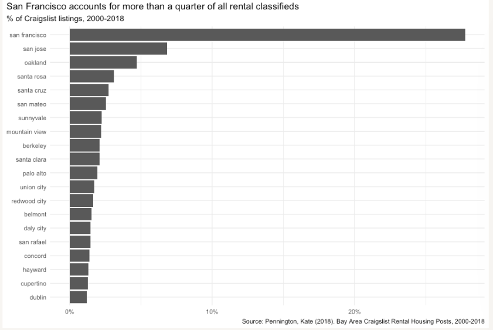

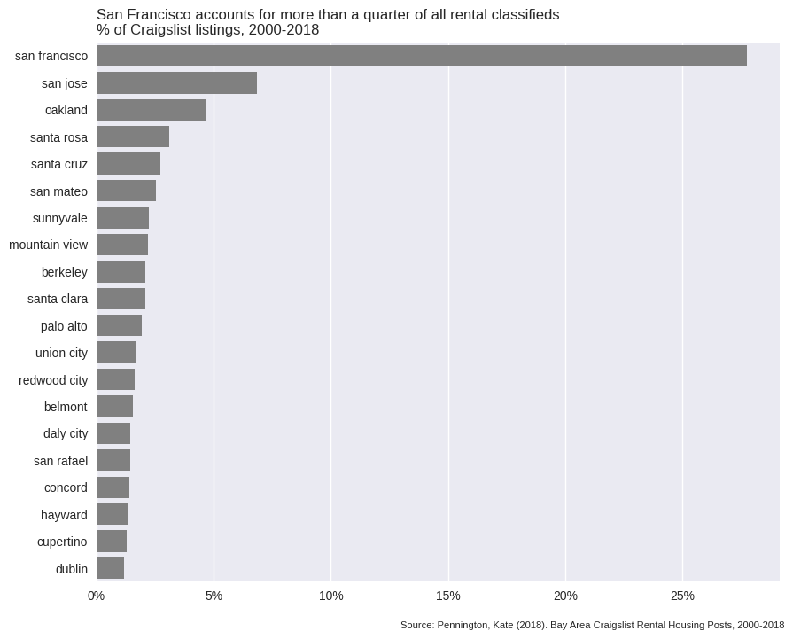

```python
# Top 20 cities by percentage of listings

# Share of all listings held by each city (as a %), keeping the 20 largest.
top20_cities = (
    rent["city"]
    .value_counts()
    #.value_counts(normalize=True)
    .reset_index(name="n_listings")
    .assign(pct_listings=lambda d: d["n_listings"] / d["n_listings"].sum() * 100)
    .rename(columns={"index": "city"})
    .head(20)
)

top20_cities = (
    rent
    .groupby("city")
    .size()
    .reset_index(name="n_listings")
    .assign(pct_listings=lambda d: d["n_listings"] / d["n_listings"].sum() * 100)
    .sort_values("pct_listings", ascending=False)
    .head(20)
)


plt.figure(figsize=(9, 7))
ax = sns.barplot(data=top20_cities, x="pct_listings", y="city", color="grey")
ax.xaxis.set_major_formatter(mtick.PercentFormatter(decimals=0))  # values already in %
ax.set(xlabel="", ylabel="")
plt.title("San Francisco accounts for more than a quarter of all rental classifieds\n"
          "% of Craigslist listings, 2000-2018", loc="left")
plt.figtext(0.99, -0.02,
            "Source: Pennington, Kate (2018). Bay Area Craigslist Rental Housing Posts, 2000-2018",
            ha="right", fontsize=8)
plt.tight_layout()
plt.show()
```

## Median prices in San Francisco by bedrooms

Make a plot that shows the evolution of median prices in San Francisco for 0, 1, 2, and 3 bedrooms listings. The final graph should resemble this

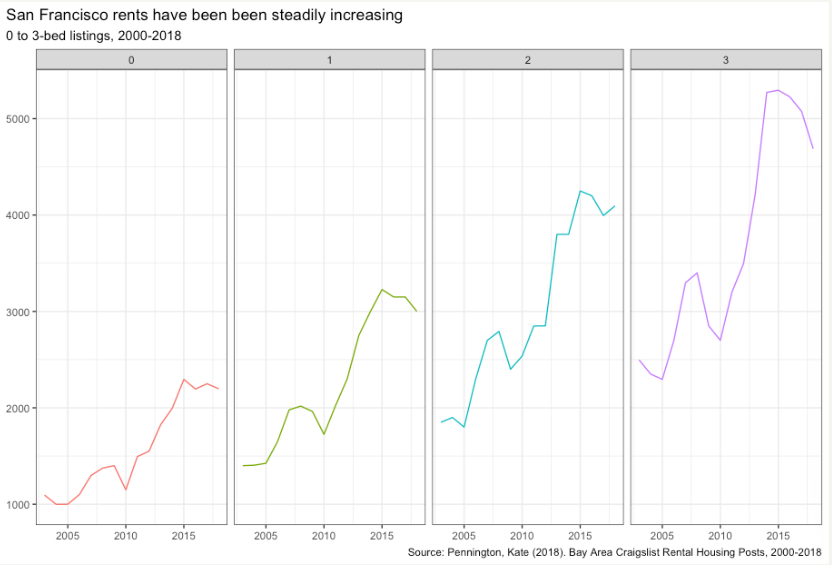

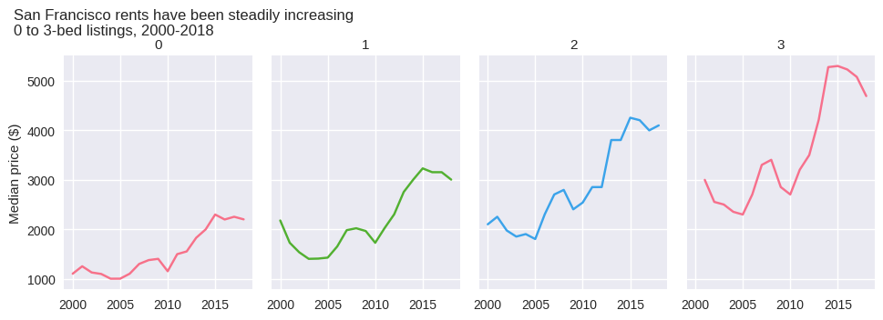

```python
# Time-series of median rents in San Francisco (0-3 bedrooms)

# Data Prep: keep SF listings for 0-3 beds, then the median price per year and bedroom count.
sf_by_beds = (
    rent
    .query("city == 'san francisco' and beds in [0, 1, 2, 3]")
    .astype({"beds": "int"})          # 0.0 -> 0 so the facet titles read cleanly
    .groupby(["year", "beds"], as_index=False)["price"]
    .median()
)

# One facet per bedroom count, each its own coloured line (matches the target layout).
g = sns.relplot(
    data=sf_by_beds,
    x="year", y="price",
    col="beds", hue="beds",
    kind="line", palette="husl",
    height=3.5, aspect=0.7, legend=False,
)
g.set_titles("{col_name}")
g.set_axis_labels("", "Median price ($)")
g.fig.suptitle("San Francisco rents have been steadily increasing\n0 to 3-bed listings, 2000-2018",
               y=1.05, x=0.02, ha="left")
```

## Median rents for the top 12 Bay Area cities

Finally, make a plot that shows median rental prices for the top 12 cities in the Bay area (for 1 bedroom rentals). Your final graph should look like this

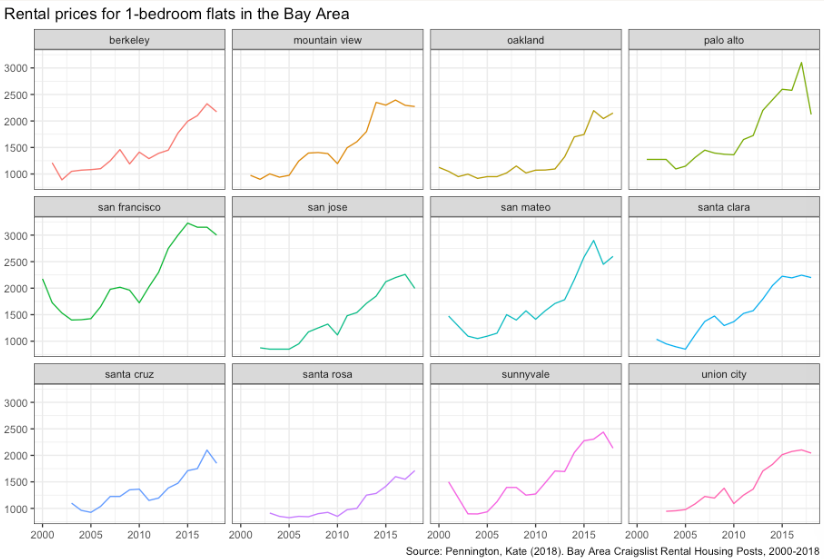

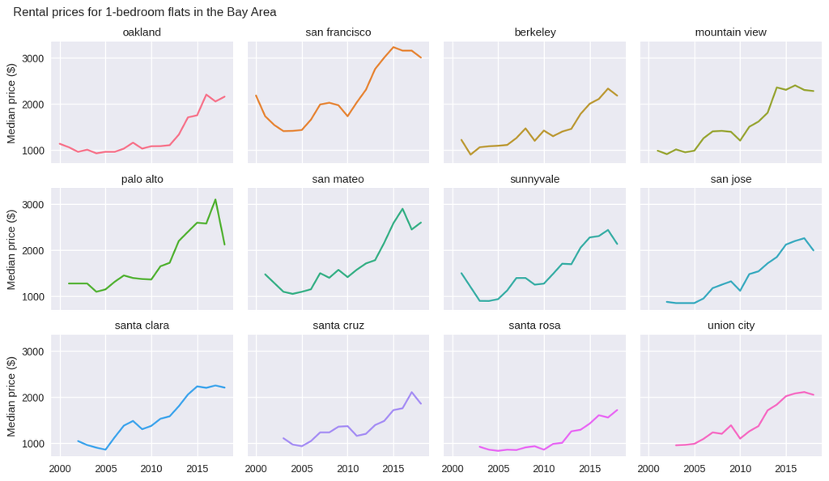

```python
# Median rental prices for top 12 cities (in terms of number of ads) in Bay Area

# The 12 cities with the most listings overall.
top12 = rent["city"].value_counts().head(12).index

# For 1-bedroom flats only, the median price per year in each of those cities.
onebed = (
    rent
    .query("beds == 1 and city in @top12")
    .groupby(["year", "city"], as_index=False)["price"]
    .median()
)

g = sns.relplot(
    data=onebed,
    x="year", y="price",
    col="city", hue="city",
    col_wrap=4, kind="line",
    height=2.2, aspect=1.3, legend=False,
)
g.set_titles("{col_name}")
g.set_axis_labels("", "Median price ($)")
g.fig.suptitle("Rental prices for 1-bedroom flats in the Bay Area", y=1.02, x=0.02, ha="left")
```

What can you infer from these plots? Don't just explain what's in the graph, but speculate or tell a short story (1-2 paragraphs max).

> TYPE YOUR ANSWER AFTER (AND OUTSIDE!) THIS BLOCKQUOTE.

The most plausible story is the tech boom: as well-paid engineering jobs flooded into San Francisco and the surrounding cities (Mountain View, Palo Alto, Sunnyvale), demand for housing surged while new construction lagged well behind. With supply effectively fixed in the short run, that extra demand showed up almost entirely as higher rents — and it rippled outward, so even cheaper commuter cities like Union City and Santa Rosa saw prices march upward in the second half of the sample.

# Deliverables

There is a lot of explanatory text, comments, etc. You do not need these, so delete them and produce a stand-alone document that you could share with someone. Save this notebook and upload it to Canvas.

# Details

**Please seek out help when you need it,** and remember the 15-minute rule. You know enough Python (and have enough examples of code from class and your readings) to be able to do this. If you get stuck, ask for help from others, use LLMs at your own risk-- and remember that I am here to help too!

> As a true test to yourself, do you understand the code you submitted and are you able to explain it to someone else?

# Rubric

Check minus (1/5): Displays minimal effort. Doesn't complete all components. Code is poorly written and not documented. Uses the same type of plot for each graph, or doesn't use plots appropriate for the variables being analyzed.

Check (3/5): Solid effort. Hits all the elements. No clear mistakes. Easy to follow (both the code and the output).

Check plus (5/5): Finished all components of the assignment correctly and addressed both challenges. Code is well-documented (both self-documented and with additional comments as necessary). Used pandas with command chaining and seaborn, instead of matplotlib. Graphs and tables are properly labelled. Analysis is clear and easy to follow, either because graphs are labeled clearly or you've written additional text to describe how you interpret the output.